# FRED inflation

## Now to do the exact same thing for the PPI Models

### PPI Model Selection

Just to make sure, the PPI models are exactly the same to the respective CPI models with the exception of the complete_lag_fit_PPI model. Whereas complete_lag_fit_CPI includes lag_diff_unemployment, complete_lag_fit_PPI does not. This will ultimately change the criteria for analyzing the results from the leaps() output slightly (as there is one less predictor variable..

```r
# complete_fit_PPI <- lm( diff_log_PPI ~ diff_log_Energy  + diff_log_Food + diff_log_Housing +   diff_log_Used_Cars + diff_Unemployment + diff_log_AvgElectricityPrices, data = final_ts_df)
#
# complete_lag_fit_PPI <- lm( diff_log_PPI ~ diff_log_Energy + lag_diff_log_Energy + diff_log_Food + lag_diff_log_Food + diff_log_Housing  +  diff_log_Used_Cars +  diff_Unemployment + diff_log_AvgElectricityPrices, data = final_ts_df)


complete_PPI.leaps.cp <- leaps(y = final_ts_df$diff_log_PPI, x = final_ts_df[,c(11,14,21,24,26,29)], method = c("Cp"))
complete_PPI.full.cp <- cbind(complete_PPI.leaps.cp$which, complete_PPI.leaps.cp$Cp)
complete_PPI.full.cp
```

```
##   1 2 3 4 5 6
## 1 1 0 0 0 0 0  59.253895
## 1 0 0 1 0 0 0 335.482152
## 1 0 1 0 0 0 0 350.418977
## 1 0 0 0 0 1 0 366.821319
## 1 0 0 0 0 0 1 411.795993
## 1 0 0 0 1 0 0 421.505222
## 2 1 0 1 0 0 0  18.931470
## 2 1 0 0 0 0 1  46.286707
## 2 1 1 0 0 0 0  47.093426
## 2 1 0 0 0 1 0  58.191217
## 2 1 0 0 1 0 0  60.202765
## 2 0 1 1 0 0 0 256.855587
## 2 0 0 1 0 1 0 279.693800
## 2 0 1 0 0 1 0 302.196124
```

[output cut: 29 more lines]

From the results above, the model that produces a Mallow’s Cp closest to the number of predictor variables in the complete_PPI model (6) is the model(1 1 1 0 1 1 5.802378) that excludes diff_log_Used_Cars. However, going with the model that minimizes Mallow’s Cp (1 1 1 0 1 0 3.822223) excludes diff_log_Used_Cars & diff_log_AvgElectricityPrices.

```r
complete_lag_PPI.leaps.cp <- leaps(y = final_ts_df$diff_log_PPI, x = final_ts_df[,c(11, 12, 14, 15, 21, 24,26, 29)], method = c("Cp"))
complete_lag_PPI.full.cp <- cbind(complete_lag_PPI.leaps.cp$which, complete_lag_PPI.leaps.cp$Cp)
complete_lag_PPI.full.cp
```

```
##   1 2 3 4 5 6 7 8
## 1 1 0 0 0 0 0 0 0  94.334508
## 1 0 1 0 0 0 0 0 0 340.600963
## 1 0 0 0 1 0 0 0 0 392.526480
## 1 0 0 0 0 1 0 0 0 394.068320
## 1 0 0 1 0 0 0 0 0 410.276189
## 1 0 0 0 0 0 0 1 0 428.074283
## 1 0 0 0 0 0 0 0 1 476.876062
## 1 0 0 0 0 0 1 0 0 487.411494
## 2 1 0 0 0 1 0 0 0  50.410669
## 2 1 0 0 1 0 0 0 0  58.201947
## 2 1 1 0 0 0 0 0 0  63.898959
## 2 1 0 0 0 0 0 0 1  80.093692
## 2 1 0 1 0 0 0 0 0  80.969058
## 2 1 0 0 0 0 0 1 0  93.011212
```

[output cut: 53 more lines]

From the results above, the model that produces a Mallow’s Cp closest to the number of predictor variables in the complete_lag_fit_PPI model (8) is the model(1 1 1 1 1 0 1 1 7.538150) that excludes diff_log_Used_Cars. However, going with the model that minimizes Mallow’s Cp (1 1 1 1 1 0 0 0 4.152958) excludes diff_log_Used_Cars, diff_Unemployment, & diff_log_AvgElectricityPrices.

```r
complete_PPI.leaps.r <- leaps(y = final_ts_df$diff_log_PPI, x = final_ts_df[,c(11,14,21,24,26,29)], method = c("adjr2"))
complete_PPI.full.r <- cbind(complete_PPI.leaps.r$which, complete_PPI.leaps.r$adjr2)
complete_PPI.full.r
```

```
##   1 2 3 4 5 6
## 1 1 0 0 0 0 0 0.47409914
## 1 0 0 1 0 0 0 0.12172242
## 1 0 1 0 0 0 0 0.10266793
## 1 0 0 0 0 1 0 0.08174391
## 1 0 0 0 0 0 1 0.02437097
## 1 0 0 0 1 0 0 0.01198518
## 2 1 0 1 0 0 0 0.52675560
## 2 1 0 0 0 0 1 0.49176071
## 2 1 1 0 0 0 0 0.49072869
## 2 1 0 0 0 1 0 0.47653156
## 2 1 0 0 1 0 0 0.47395823
## 2 0 1 1 0 0 0 0.22238503
## 2 0 0 1 0 1 0 0.19316865
## 2 0 1 0 0 1 0 0.16438197
```

[output cut: 29 more lines]

So it seems that from the complete_fit_PPI model, based on getting the maximum Adjusted R-Squared value, the best model to go with is (1 1 1 0 1 0 0.54850982) which is the model that excludes diff_log_Used_Cars and diff_log_AvgElectricityPrices.

```r
complete_lag_PPI.leaps.r <- leaps(y = final_ts_df$diff_log_PPI, x = final_ts_df[,c(11, 12, 14, 15, 21, 24,26, 29)], method = c("adjr2"))
complete_lag_PPI.full.r <- cbind(complete_lag_PPI.leaps.r$which, complete_lag_PPI.leaps.r$adjr2)
complete_lag_PPI.full.r
```

```
##   1 2 3 4 5 6 7 8
## 1 1 0 0 0 0 0 0 0 0.47409914
## 1 0 1 0 0 0 0 0 0 0.18458037
## 1 0 0 0 1 0 0 0 0 0.12353506
## 1 0 0 0 0 1 0 0 0 0.12172242
## 1 0 0 1 0 0 0 0 0 0.10266793
## 1 0 0 0 0 0 0 1 0 0.08174391
## 1 0 0 0 0 0 0 0 1 0.02437097
## 1 0 0 0 0 0 1 0 0 0.01198518
## 2 1 0 0 0 1 0 0 0 0.52675560
## 2 1 0 0 1 0 0 0 0 0.51757005
## 2 1 1 0 0 0 0 0 0 0.51085354
## 2 1 0 0 0 0 0 0 1 0.49176071
## 2 1 0 1 0 0 0 0 0 0.49072869
## 2 1 0 0 0 0 0 1 0 0.47653156
```

[output cut: 53 more lines]

From the complete_lag_fit_PPI, the model that achieves the largest adjusted R-squared value would be (1 1 1 1 1 0 0 0 0.58475515) which excludes diff_log_Used_Cars, diff_Unemployment, diff_log_AvgElectricityPrices.

```r
stepAIC(complete_fit_PPI, direction = "backward")
```

```
## Start:  AIC=-3607.59
## diff_log_PPI ~ diff_log_Energy + diff_log_Food + diff_log_Housing +
##     diff_log_Used_Cars + diff_Unemployment + diff_log_AvgElectricityPrices
##
##                                 Df Sum of Sq      RSS     AIC
## - diff_log_AvgElectricityPrices  1 0.0000000 0.014027 -3609.6
## - diff_log_Used_Cars             1 0.0000338 0.014061 -3608.7
## <none>                                       0.014027 -3607.6
## - diff_Unemployment              1 0.0001066 0.014134 -3606.9
## - diff_log_Food                  1 0.0006340 0.014661 -3593.8
## - diff_log_Housing               1 0.0010754 0.015102 -3583.2
## - diff_log_Energy                1 0.0083447 0.022372 -3442.9
##
## Step:  AIC=-3609.59
## diff_log_PPI ~ diff_log_Energy + diff_log_Food + diff_log_Housing +
##     diff_log_Used_Cars + diff_Unemployment
##
##                      Df Sum of Sq      RSS     AIC
## - diff_log_Used_Cars  1 0.0000339 0.014061 -3610.7
## <none>                            0.014027 -3609.6
## - diff_Unemployment   1 0.0001066 0.014134 -3608.9
## - diff_log_Food       1 0.0006385 0.014666 -3595.7
## - diff_log_Housing    1 0.0017814 0.015808 -3568.9
## - diff_log_Energy     1 0.0083854 0.022412 -3444.3
##
## Step:  AIC=-3610.72
## diff_log_PPI ~ diff_log_Energy + diff_log_Food + diff_log_Housing +
##     diff_Unemployment
##
##                     Df Sum of Sq      RSS     AIC
## <none>                           0.014061 -3610.7
## - diff_Unemployment  1 0.0001111 0.014172 -3609.9
## - diff_log_Food      1 0.0006375 0.014698 -3596.9
## - diff_log_Housing   1 0.0017857 0.015847 -3570.0
## - diff_log_Energy    1 0.0085752 0.022636 -3442.7
```

```
##
## Call:
## lm(formula = diff_log_PPI ~ diff_log_Energy + diff_log_Food +
##     diff_log_Housing + diff_Unemployment, data = final_ts_df)
##
## Coefficients:
##       (Intercept)    diff_log_Energy      diff_log_Food   diff_log_Housing
##        -0.0003189          0.0759135          0.0469322          0.8798459
## diff_Unemployment
##        -0.0981452
```

```r
stepAIC(complete_lag_fit_PPI, direction = "backward")
```

```
## Start:  AIC=-3634.79
## diff_log_PPI ~ diff_log_Energy + lag_diff_log_Energy + diff_log_Food +
##     lag_diff_log_Food + diff_log_Housing + diff_log_Used_Cars +
##     diff_Unemployment + diff_log_AvgElectricityPrices
##
##                                 Df Sum of Sq      RSS     AIC
## - diff_log_AvgElectricityPrices  1 0.0000015 0.012855 -3636.7
## - diff_Unemployment              1 0.0000183 0.012871 -3636.3
## - diff_log_Used_Cars             1 0.0000208 0.012874 -3636.2
## <none>                                       0.012853 -3634.8
## - diff_log_Food                  1 0.0004250 0.013278 -3625.2
## - lag_diff_log_Food              1 0.0004337 0.013287 -3624.9
## - lag_diff_log_Energy            1 0.0004904 0.013344 -3623.4
## - diff_log_Housing               1 0.0006744 0.013528 -3618.5
## - diff_log_Energy                1 0.0064999 0.019353 -3490.7
##
## Step:  AIC=-3636.75
## diff_log_PPI ~ diff_log_Energy + lag_diff_log_Energy + diff_log_Food +
##     lag_diff_log_Food + diff_log_Housing + diff_log_Used_Cars +
##     diff_Unemployment
##
##                       Df Sum of Sq      RSS     AIC
## - diff_Unemployment    1 0.0000183 0.012873 -3638.2
## - diff_log_Used_Cars   1 0.0000215 0.012876 -3638.2
## <none>                             0.012855 -3636.7
## - diff_log_Food        1 0.0004236 0.013278 -3627.2
## - lag_diff_log_Food    1 0.0004325 0.013287 -3626.9
## - lag_diff_log_Energy  1 0.0004898 0.013345 -3625.4
## - diff_log_Housing     1 0.0011715 0.014026 -3607.6
## - diff_log_Energy      1 0.0065119 0.019367 -3492.4
##
## Step:  AIC=-3638.24
## diff_log_PPI ~ diff_log_Energy + lag_diff_log_Energy + diff_log_Food +
##     lag_diff_log_Food + diff_log_Housing + diff_log_Used_Cars
##
##                       Df Sum of Sq      RSS     AIC
## - diff_log_Used_Cars   1 0.0000224 0.012895 -3639.6
## <none>                             0.012873 -3638.2
## - lag_diff_log_Food    1 0.0004246 0.013298 -3628.7
## - diff_log_Food        1 0.0004300 0.013303 -3628.5
## - lag_diff_log_Energy  1 0.0005763 0.013449 -3624.6
## - diff_log_Housing     1 0.0011646 0.014038 -3609.3
## - diff_log_Energy      1 0.0070467 0.019920 -3484.4
##
## Step:  AIC=-3639.62
## diff_log_PPI ~ diff_log_Energy + lag_diff_log_Energy + diff_log_Food +
##     lag_diff_log_Food + diff_log_Housing
##
##                       Df Sum of Sq      RSS     AIC
## <none>                             0.012895 -3639.6
## - lag_diff_log_Food    1 0.0004226 0.013318 -3630.1
## - diff_log_Food        1 0.0004297 0.013325 -3629.9
## - lag_diff_log_Energy  1 0.0005918 0.013487 -3625.6
## - diff_log_Housing     1 0.0011655 0.014061 -3610.7
## - diff_log_Energy      1 0.0071799 0.020075 -3483.6
```

```
##
## Call:
## lm(formula = diff_log_PPI ~ diff_log_Energy + lag_diff_log_Energy +
##     diff_log_Food + lag_diff_log_Food + diff_log_Housing, data = final_ts_df)
##
## Coefficients:
##         (Intercept)      diff_log_Energy  lag_diff_log_Energy
##          -0.0001223            0.0698683            0.0197447
##       diff_log_Food    lag_diff_log_Food     diff_log_Housing
##           0.0391824            0.0396509            0.7273450
```

From the above analysis on PPI, it seems like it might be appropriate to exclude all predictor variables related to Used Cars, Unemployment, & Average electricity prices. With this in mind, I will go ahead and build what could be considered a “final” PPI model w/ & w/o relevant lags.

## “Final” PPI Models

```r
final_fit_PPI <- lm( diff_log_PPI ~ diff_log_Energy  + diff_log_Food + diff_log_Housing, data = final_ts_df)

final_lag_fit_PPI <- lm( diff_log_PPI ~ diff_log_Energy + lag_diff_log_Energy + diff_log_Food + lag_diff_log_Food + diff_log_Housing, data = final_ts_df)
```

```r
modelsummary(list(
  "final_PPI"=final_fit_PPI,
  "final_PPI_w_lags"=final_lag_fit_PPI),estimate="{estimate}{stars}")
```

|  | final_PPI | final_PPI_w_lags |
| --- | --- | --- |
| (Intercept) | 0.000 | 0.000 |
|  | (0.000) | (0.000) |
| diff_log_Energy | 0.079*** | 0.070*** |
|  | (0.005) | (0.005) |
| diff_log_Food | 0.048*** | 0.039*** |
|  | (0.012) | (0.011) |
| diff_log_Housing | 0.879*** | 0.727*** |
|  | (0.132) | (0.129) |
| lag_diff_log_Energy |  | 0.020*** |
|  |  | (0.005) |
| lag_diff_log_Food |  | 0.040*** |
|  |  | (0.012) |
| Num.Obs. | 357 | 357 |
| R2 | 0.550 | 0.591 |
| R2 Adj. | 0.546 | 0.585 |
| AIC | -2594.8 | -2624.5 |
| BIC | -2575.4 | -2597.4 |
| Log.Lik. | 1302.396 | 1319.248 |
| F | 143.910 | 101.308 |

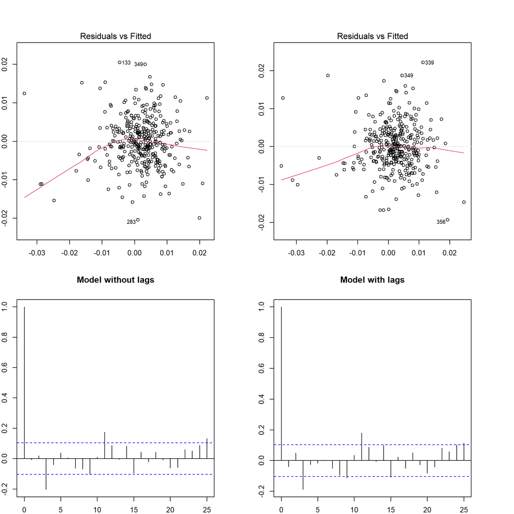

```r
par(mar = c(2,2,5,5))
par(mfrow=c(2,2))
plot(final_fit_PPI,which=c(1))
plot(final_lag_fit_PPI,which=c(1))
acf(final_fit_PPI$residuals,main="Model without lags")
acf(final_lag_fit_PPI$residuals,main="Model with lags")
```

## Investigating if PPI and CPI affects PPI: Ultimately, as everyday people, we are more concerned with CPI. As seen above, we have a model that parsimoniously describes some of the variables that can affect CPI. However, we want to know if PPI itself can affect CPI, by virtue of the producers passing on costs to consumers. Additionally, we want to see if CPI itself has autocrrelation.

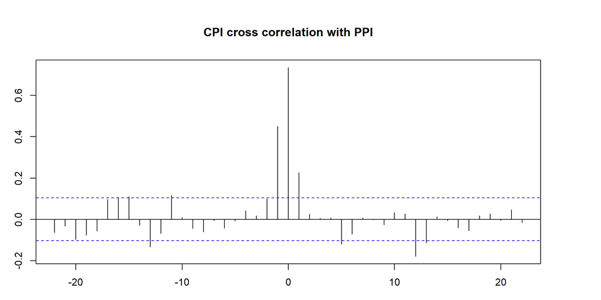

```r
par(mar = c(3,3,5,5))
ccf(x=final_ts_df$diff_log_PPI,y=final_ts_df$diff_log_CPI,main="CPI cross correlation with PPI")
```

```r
final_ts_df['lag_diff_log_PPI']=lag(final_ts_df$diff_log_PPI,1)
final_lag_fit_full_CPI <- dynlm( diff_log_CPI ~ diff_log_PPI+lag_diff_log_PPI+diff_log_Energy + lag_diff_log_Energy + diff_log_Housing  +  diff_log_Used_Cars + diff_log_AvgElectricityPrices, data = final_ts_df)
```

```r
modelsummary(list(
  "final_model_without_PPI"=final_lag_fit_CPI,
  "final_model_with_PPI"=final_lag_fit_full_CPI
),estimate="{estimate}{stars}")
```

|  | final_model_without_PPI | final_model_with_PPI |
| --- | --- | --- |
| (Intercept) | 0.001*** | 0.001*** |
|  | (0.000) | (0.000) |
| diff_log_Energy | 0.014*** | 0.005** |
|  | (0.001) | (0.002) |
| lag_diff_log_Energy | 0.014*** | 0.008*** |
|  | (0.001) | (0.002) |
| diff_log_Housing | 0.268*** | 0.156*** |
|  | (0.047) | (0.043) |
| diff_log_Used_Cars | 0.033*** | 0.029*** |
|  | (0.007) | (0.007) |
| diff_log_AvgElectricityPrices | -0.012* | -0.012* |
|  | (0.006) | (0.005) |
| diff_log_PPI |  | 0.132*** |
|  |  | (0.013) |
| lag_diff_log_PPI |  | 0.036** |
|  |  | (0.012) |
| Num.Obs. | 357 | 356 |
| R2 | 0.569 | 0.675 |
| R2 Adj. | 0.563 | 0.669 |
| AIC | -3510.4 | -3596.5 |
| BIC | -3483.2 | -3561.7 |
| Log.Lik. | 1762.184 | 1807.271 |
| F | 92.786 | 103.423 |

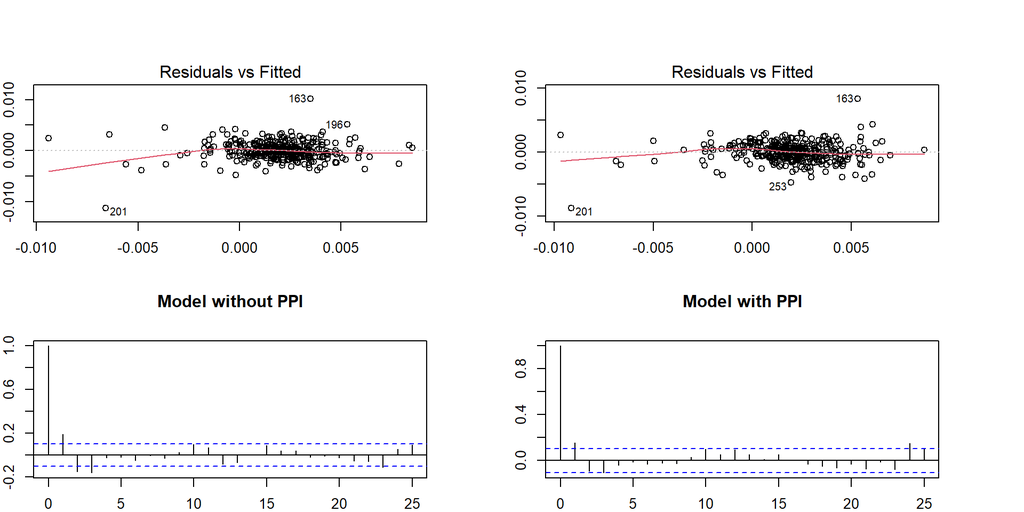

```r
par(mar = c(2,2,5,5))
par(mfrow=c(2,2))
plot(final_lag_fit_CPI,which=c(1))
plot(final_lag_fit_full_CPI,which=c(1))
acf(final_lag_fit_CPI$residuals,main="Model without PPI")
acf(final_lag_fit_full_CPI$residuals,main="Model with PPI")
```

## Summary:

We found that the energy prices currently and in the previous period, food prices currently and in the previous period, and housing prices are strong, positive correlated predictors for PPI. Energy prices and food prices make sense, given that they are common inputs for production processes. However, housing seems to be an anomalous predictor as there should be no reason why producers should care about housing prices, unless it affects their rent.

We found that the energy prices currently and in the previous period, housing prices, used cars prices, PPI currently and in the previous period are positively correlated predictors for CPI. This makes sense as these are items that factor into the current calculation for CPI, while PPI factors indirectly because producers, facing higher costs, will pass on some/all of the costs to consumers, leading to price raises for purchased goods. However, the negative correlation with average electricity prices seems anomalous, as the intuition is in the opposite direction: higher electricity prices should feed through all processes that utilize electricity, leading to price increases across the board.